# Projeck R Markdown

Kelompok 4

2024-10-07

**Nama anggota kelompok 4:**  
1. J.H. Isabel D. Gultom (F1F023014)  
2. A’inun Fauziyah (F1F023017)  
3. Arum Pujiastuti (F1F023021)  
4. Reva Amelia (F1F023022)

## Diagram Kendali (Data Atribut Defective)

Berikut adalah **projeck komstat kelompok 4**, pada projeck kali ini kami membuat sebuah fungsi untuk memunculkan diagram kendali. Dimana diagram kendali sendiri merupakan sebuah diagram untuk memetakan kualitas (atribut ataupun variabel) dari waktu ke waktu. Diagram kendali yang ingin kami tampilkan adalah diagram kendali untuk data atribut (diskrit). Disini kami memilih diagram kendali atribut untuk defective yang artinya diagram ini mengacu pada seluruh unit yang ada. Yang mana jenis diagram kendalinya adalah diagram P dan diagram NP Disini kami menggunakan sebuah data dari Pia Bread untuk mencoba fungsi yang kami buat, berikut fungsi yang kami sajikan:

## Memuat Library dan Data

```r
# Memuat library yang diperlukan
library(readxl)
library(knitr)
# Baca data dari file Excel
DATAKOMSTAT <- read_excel("D:/SEMESTER 3/Komputasi Statistika/DATAKOMSTAT.xlsx")

kable(DATAKOMSTAT)
```

| Hari ke | jumlah produksi | jumlah produk cacat |
| --- | --- | --- |
| 1 | 1000 | 61 |
| 2 | 1000 | 65 |
| 3 | 1000 | 61 |
| 4 | 1000 | 59 |
| 5 | 1000 | 52 |
| 6 | 1000 | 59 |
| 7 | 1000 | 60 |
| 8 | 1000 | 54 |
| 9 | 1000 | 58 |
| 10 | 1000 | 66 |
| 11 | 1000 | 65 |
| 12 | 1000 | 58 |
| 13 | 1000 | 58 |
| 14 | 1000 | 61 |
| 15 | 1000 | 58 |
| 16 | 1000 | 69 |
| 17 | 1000 | 71 |
| 18 | 1000 | 64 |
| 19 | 1000 | 66 |
| 20 | 1000 | 56 |
| 21 | 1000 | 58 |
| 22 | 1000 | 65 |
| 23 | 1000 | 60 |
| 24 | 1000 | 59 |
| 25 | 1000 | 66 |
| 26 | 1000 | 88 |
| 27 | 1000 | 70 |
| 28 | 1000 | 52 |
| 29 | 1000 | 63 |
| 30 | 1000 | 49 |

Ini merupakan fungsi untuk membaca file Excel dan menampilkan data dalam jendela Rstudio

## Diagram Kendali P

Diagram kendali P adalah diagram kontrol dari bagian yang tidak memenuhi syarat, menunjukkan proporsi cacat (cacat keseluruhan), Berikut adalah fungsinya

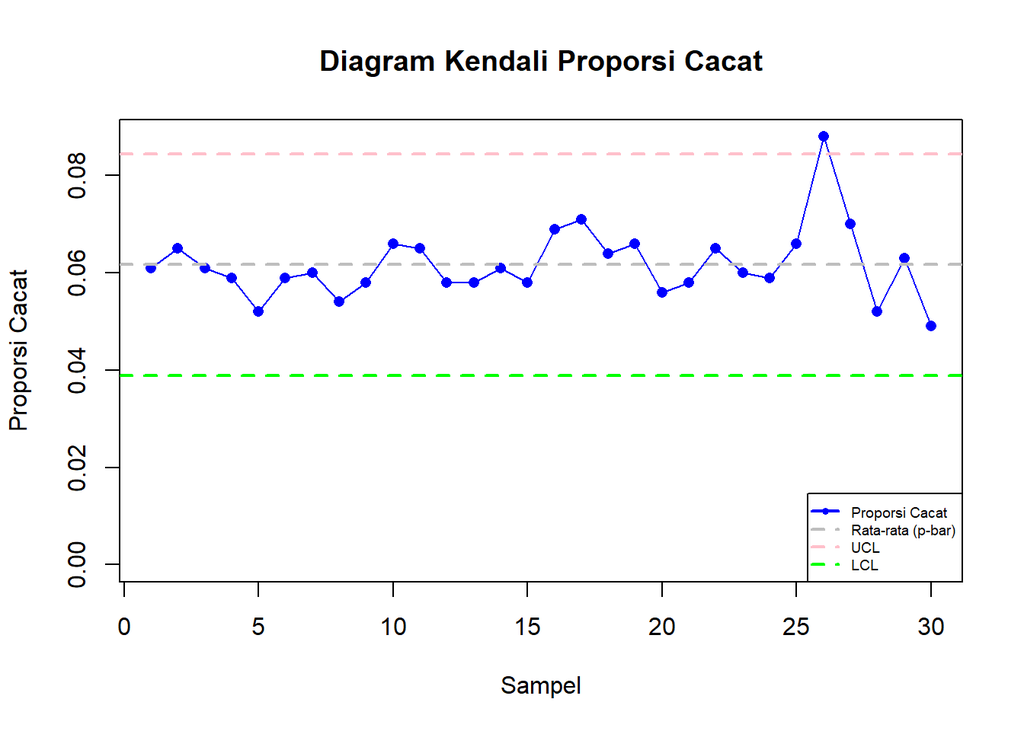

```r
#Diagram kendali p
Diagram_kendali_P <- function(cacat, sampel, judul = "Diagram Kendali p") {
  # Fungsi untuk periksa apakah panjang cacat dan sampel sama pada
  if (length(cacat) != length(sampel)) {
    stop("jumlah data produk cacat dan sampel harus sama.")
  }

  # Hitung proporsi cacat untuk setiap sampel
  proporsi <- cacat / sampel

  # Hitung rata-rata proporsi cacat (p-bar)
  p_bar <- mean(proporsi)

  # Hitung batas pengendalian atas (UCL) dan bawah (LCL) Menggunakan ukuran sampel rata-rata
  n_bar <- mean(sampel)  # Menggunakan variabel sampel di sini
  UCL <- p_bar + 3 * sqrt(p_bar * (1 - p_bar) / n_bar)
  LCL <- p_bar - 3 * sqrt(p_bar * (1 - p_bar) / n_bar)

  # LCL tidak boleh kurang dari 0
  LCL <- max(LCL, 0)

  # Plot grafik diagram kendali p
  plot(proporsi, type = "o", pch = 16, col = "blue", ylim = c(0, max(UCL, max(proporsi))),
       xlab = "Sampel", ylab = "Proporsi Cacat", main = judul)
  abline(h = p_bar, col = "grey", lwd = 2, lty = 2)  # Garis p-bar
  abline(h = UCL, col = "pink", lwd = 2, lty = 2)      # Garis UCL
  abline(h = LCL, col = "green", lwd = 2, lty = 2)      # Garis LCL

  # Tambahkan keterangan
  legend("bottomright", legend = c("Proporsi Cacat", "Rata-rata (p-bar)", "UCL", "LCL"),
         col = c("blue", "grey", "pink", "green"), lty = c(1, 2, 2, 2), lwd = 2, pch = c(16, NA, NA, NA),cex=0.6)
}

# Panggil fungsi untuk membuat peta kendali p
Diagram_kendali_P(DATAKOMSTAT$`jumlah produk cacat`, DATAKOMSTAT$`jumlah produksi`, judul = "Diagram Kendali Proporsi Cacat")
```

## Diagram Kendali NP

Diagram kendali NP merupakan diagram kontrol yang menunjukkan jumlah cacat dalam suatu populasi

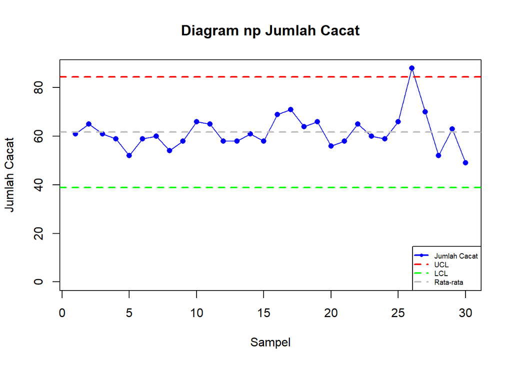

```r
# Fungsi untuk membuat diagram np
Diagram_np <- function(cacat, ukuran, judul = "Diagram np") {
  # Periksa apakah panjang cacat dan ukuran sama
  if (length(cacat) != length(ukuran)) {
    stop("Jumlah produk cacat dan ukuran sampel harus sama.")
  }

  # Hitung batas pengendalian
  n <- mean(ukuran)  # ukuran sampel rata-rata
  p_bar <- sum(cacat) / sum(ukuran)  # rata-rata proporsi cacat
  UCL <- n * p_bar + 3 * sqrt(n * p_bar * (1 - p_bar))  # Batas atas
  LCL <- max(0, n * p_bar - 3 * sqrt(n * p_bar * (1 - p_bar)))  # Batas bawah

  # Plot diagram np
  plot(cacat, type = "o", pch = 16, col = "blue", ylim = c(0, max(UCL, max(cacat))),
       xlab = "Sampel", ylab = "Jumlah Cacat", main = judul)
  abline(h = UCL, col = "red", lwd = 2, lty = 2)  # Garis UCL
  abline(h = LCL, col = "green", lwd = 2, lty = 2)  # Garis LCL
  abline(h = n * p_bar, col = "grey", lwd = 2, lty = 2)  # Garis rata-rata

  # Tambahkan keterangan
  legend("bottomright", legend = c("Jumlah Cacat", "UCL", "LCL", "Rata-rata"),
         col = c("blue", "red", "green", "grey"), lty = c(1, 2, 2, 2), lwd = 2, pch = c(16, NA, NA, NA), cex = 0.6)
}

# Panggil fungsi untuk membuat diagram np
Diagram_np(DATAKOMSTAT$`jumlah produk cacat`, DATAKOMSTAT$`jumlah produksi`, judul = "Diagram np Jumlah Cacat")
```

Sekian projeck kami mengenai fungsi diagram kendali Data atribut defective